# Analysis & Bias Correction of Forecast Data

###### Contents

```
1. Exploratory Analysis
2. Data Preprocessing
3. Analysis of Best Model Forecast
4. Bias Correction of Forecasts
```

```python
import pandas as pd
import numpy as np
import matplotlib.pyplot as plt
from sklearn.metrics import mean_squared_error, r2_score
import seaborn as sns
from sklearn.model_selection import train_test_split
from sklearn.ensemble import GradientBoostingRegressor
from analysis_functions import Preprocessing, Bias_Correction
import os
```

```python
# load in datasets
# set index to observational time stamp
BOS_obs = pd.read_csv("data/KBOS/obs.csv",index_col=0,parse_dates=True)
HLC_obs = pd.read_csv("data/KHLC/obs.csv",index_col=0,parse_dates=True)

# set indexes to forecast time stamp | convert DatetimeIndex tzUTC-obj to normal DatetimeIndex
BOS_hrrr = pd.read_csv("data/KBOS/HRRR.csv",index_col=2,parse_dates=True).tz_convert(None)
BOS_gfs = pd.read_csv("data/KBOS/GFS.csv",index_col=2,parse_dates=True).tz_convert(None)
BOS_ecmwf = pd.read_csv("data/KBOS/ECMWF.csv",index_col=2,parse_dates=True).tz_convert(None)
HLC_hrrr = pd.read_csv("data/KHLC/HRRR.csv",index_col=2,parse_dates=True).tz_convert(None)
HLC_gfs = pd.read_csv("data/KHLC/GFS.csv",index_col=2,parse_dates=True).tz_convert(None)
HLC_ecmwf = pd.read_csv("data/KHLC/ECMWF.csv",index_col=2,parse_dates=True).tz_convert(None)
```

```python
# combine both KHLC and KBOS data for analysis
obs = pd.concat([BOS_obs,HLC_obs])
hrrr = pd.concat([BOS_hrrr,HLC_hrrr])
gfs = pd.concat([BOS_gfs,HLC_gfs])
ecmwf = pd.concat([BOS_ecmwf,HLC_ecmwf])
```

### 1. Exploratory Analysis of the data

```python
# find max/min range of observational dataset
obs_max = obs.index.max()
obs_min = obs.index.min()

print(f"Observational Date Range: {obs_min} to {obs_max}")
```

```
Observational Date Range: 2021-06-01 00:00:00 to 2021-07-01 00:00:00
```

```python
# check for missing hours from the data (only use the date-range of the observational data)
missing_hours_obs = pd.date_range(start = '2021-06-1', end = '2021-07-1',freq='H').difference(obs.index)
missing_hours_hrrr = pd.date_range(start = '2021-06-1', end = '2021-07-1',freq='H').difference(hrrr.index)
missing_hours_gfs = pd.date_range(start = '2021-06-1', end = '2021-07-1',freq='H').difference(gfs.index)
missing_hours_ecmwf = pd.date_range(start = '2021-06-1', end = '2021-07-1',freq='H').difference(ecmwf.index)

print(f"Missing hours observational data: {missing_hours_obs.values}")
print(f"Missing hours HRRR data: {missing_hours_hrrr.values}")
print(f"Missing hours GFS data: {missing_hours_gfs.values}")
print(f"Missing hours ECMWF data: {missing_hours_ecmwf.values}")
```

```
Missing hours observational data: []
Missing hours HRRR data: []
Missing hours GFS data: ['2021-06-01T00:00:00.000000000' '2021-06-01T01:00:00.000000000']
Missing hours ECMWF data: ['2021-06-01T00:00:00.000000000']
```

```python
# sum missing vals
obs.isna().sum()
```

```
icao                0
temperature_k      20
dewpoint_k         21
wind_speed_mps     24
sfc_press_pa        2
cloud_cover       849
dtype: int64
```

```python
# obs descr. statistics
obs.describe()
```

|  | temperature_k | dewpoint_k | wind_speed_mps | sfc_press_pa | cloud_cover |
| --- | --- | --- | --- | --- | --- |
| count | 1416.000000 | 1415.000000 | 1412.000000 | 1434.000000 | 587.000000 |
| mean | 297.524364 | 288.580628 | 4.212921 | 97498.629470 | 64.650767 |
| std | 5.904731 | 4.258666 | 2.264981 | 3989.612292 | 23.862909 |
| min | 284.150000 | 277.111111 | 0.000000 | 92622.940000 | 43.750000 |
| 25% | 292.150000 | 285.250000 | 2.570480 | 93528.560000 | 43.750000 |
| 50% | 297.150000 | 289.138889 | 4.117238 | 100165.410000 | 43.750000 |
| 75% | 302.150000 | 292.138889 | 5.659526 | 101383.640000 | 87.500000 |
| max | 315.150000 | 297.222222 | 15.945917 | 102974.100000 | 100.000000 |

```python
# hrrr desc. stats
hrrr.describe()
```

|  | fcst_dt | sfc_air_temperature | sfc_dewpoint | v_wind_10m | u_wind_10m | sfc_pressure | sea_level_pressure | cloud_cover |
| --- | --- | --- | --- | --- | --- | --- | --- | --- |
| count | 5750.000000 | 5750.000000 | 5750.000000 | 5750.000000 | 5750.000000 | 5750.000000 | 5750.000000 | 5750.000000 |
| mean | 24.931826 | 22.764148 | 14.934558 | 1.406369 | 0.316416 | 1012.643201 | 974.494766 | 53.615117 |
| std | 13.608325 | 5.947356 | 3.863736 | 3.111285 | 2.824572 | 6.387029 | 40.771710 | 45.095790 |
| min | 0.000000 | 9.150000 | -0.230000 | -13.160000 | -11.260000 | 997.119995 | 923.440002 | 0.000000 |
| 25% | 13.000000 | 18.120001 | 12.300000 | -0.250000 | -1.927500 | 1008.099976 | 934.549988 | 1.880000 |
| 50% | 25.000000 | 21.790001 | 15.370000 | 1.640000 | 0.690000 | 1012.419983 | 972.414978 | 65.925003 |
| 75% | 37.000000 | 26.830000 | 18.120001 | 3.450000 | 2.550000 | 1016.687500 | 1014.119995 | 100.000000 |
| max | 48.000000 | 42.340000 | 24.330000 | 11.330000 | 13.510000 | 1031.099976 | 1030.949951 | 100.000000 |

```python
# gfs stats
gfs.describe()
```

|  | fcst_dt | sfc_air_temperature | sfc_dewpoint | v_wind_10m | u_wind_10m | sfc_pressure | sea_level_pressure | cloud_cover |
| --- | --- | --- | --- | --- | --- | --- | --- | --- |
| count | 25250.000000 | 25250.000000 | 25250.000000 | 25250.000000 | 25250.000000 | 25250.000000 | 25250.000000 | 25250.000000 |
| mean | 142.852277 | 21.201510 | 14.250137 | 0.098859 | -0.594920 | 1015.650401 | 966.594631 | 37.610523 |
| std | 110.472276 | 3.610148 | 5.078368 | 2.810436 | 2.509961 | 3.386230 | 48.938484 | 39.643010 |
| min | 2.000000 | 7.010000 | -3.240000 | -12.660000 | -12.430000 | 1002.460022 | 905.940002 | 0.000000 |
| 25% | 53.000000 | 19.180000 | 10.050000 | -1.950000 | -1.900000 | 1013.140015 | 918.099976 | 0.800000 |
| 50% | 105.000000 | 21.850000 | 14.650000 | -0.215000 | -0.320000 | 1015.849976 | 963.760010 | 18.600000 |
| 75% | 231.000000 | 23.450001 | 18.770000 | 2.010000 | 0.810000 | 1018.219971 | 1015.750000 | 78.300003 |
| max | 384.000000 | 37.360001 | 23.250000 | 11.770000 | 13.170000 | 1025.280029 | 1023.880005 | 100.000000 |

```python
# ecmwf stats
ecmwf.describe()
```

|  | fcst_dt | sfc_air_temperature | sfc_dewpoint | v_wind_10m | u_wind_10m | sfc_pressure | sea_level_pressure | cloud_cover |
| --- | --- | --- | --- | --- | --- | --- | --- | --- |
| count | 15122.000000 | 15122.000000 | 15122.000000 | 15122.000000 | 15122.000000 | 15122.000000 | 15122.000000 | 15122.000000 |
| mean | 75.389499 | 22.747916 | 15.249486 | 1.714359 | 0.456183 | 1012.594456 | 973.219649 | 47.865215 |
| std | 58.219098 | 5.500115 | 3.588779 | 3.208443 | 2.699768 | 5.677388 | 39.544192 | 40.082115 |
| min | 1.000000 | 10.600000 | -0.910000 | -14.740000 | -10.860000 | 992.820007 | 918.190002 | 0.000000 |
| 25% | 31.000000 | 18.559999 | 12.652500 | -0.170000 | -1.490000 | 1008.530029 | 934.500000 | 3.910000 |
| 50% | 62.000000 | 21.830000 | 15.490000 | 2.070000 | 0.450000 | 1012.570007 | 969.650024 | 44.529999 |
| 75% | 102.000000 | 26.330000 | 18.197501 | 3.970000 | 2.650000 | 1016.289978 | 1011.799988 | 92.190002 |
| max | 240.000000 | 42.419998 | 23.340000 | 10.100000 | 11.540000 | 1030.719971 | 1029.160034 | 100.000000 |

###### Observations & Tasks

- Data is hourly collected
- Time Range: 00z June 1 2021 - 00z July 1 2021
- GFS & ECMWF are missing the 1st hourly observation
- Observations need to be preprocessed (i.e. convert all data to the same units, calculate wind speeds, etc)
- Missing vals in the observation set
- Only interested in temperature, dewpoint, and wind speed

Max forecast hour dt is 48 (HRRR), which means in order to make a consistent analysis across all 3 models, only the forecast hours of 0-48z can be considered in order to preserve the consistency.

### 2. Data Preprocessing

```python
# convert observational data to correct units
obs_processed = obs

# convert Kelvin to Celsius | mph to m/s | pascal to mb
obs_processed["temperature_k"] = obs_processed["temperature_k"] - 273.15
obs_processed["dewpoint_k"] = obs_processed["dewpoint_k"] - 273.15
obs_processed["wind_speed_mps"] = obs_processed["wind_speed_mps"] * 0.44704

# rename columns
dict = {"temperature_k":"temperature_c","dewpoint_k":"dewpoint_c","wind_speed_mps":"wind_speed_ms"}
obs_processed = obs_processed.rename(columns=dict)

# remove cloud cover/sfcpress
obs_processed = obs_processed.drop(["sfc_press_pa","cloud_cover"],axis=1)
```

```python
# calculate wind speed for model data
gfs_processed = Preprocessing.calc_windspeed(gfs)
hrrr_processed = Preprocessing.calc_windspeed(hrrr)
ecmwf_processed = Preprocessing.calc_windspeed(ecmwf)

# only select variables of interest
gfs_processed = gfs_processed.drop(["sfc_pressure","sea_level_pressure","cloud_cover"],axis=1)
hrrr_processed = hrrr_processed.drop(["sfc_pressure","sea_level_pressure","cloud_cover"],axis=1)
ecmwf_processed = ecmwf_processed.drop(["sfc_pressure","sea_level_pressure","cloud_cover"],axis=1)
```

```python
# separate into location dataframes in order to merge together with observations
BOS_obs_processed = obs_processed[obs_processed.icao=="KBOS"]
HLC_obs_processed = obs_processed[obs_processed.icao=="KHLC"]

# gfs
BOS_gfs_processed = gfs_processed[gfs_processed.pt=="KBOS"]
HLC_gfs_processed = gfs_processed[gfs_processed.pt=="KHLC"]

#hrrr
BOS_hrrr_processed = hrrr_processed[hrrr_processed.pt=="KBOS"]
HLC_hrrr_processed = hrrr_processed[hrrr_processed.pt=="KHLC"]

# ecmwf
BOS_ecmwf_processed = ecmwf_processed[ecmwf_processed.pt=="KBOS"]
HLC_ecmwf_processed = ecmwf_processed[ecmwf_processed.pt=="KHLC"]
```

### 3. Analysis of Best Forecast

```python
# combine forecast data for each location with observational data to prepare for analysis
gfs_analysis_df = Preprocessing.merge_forecast_with_obs([BOS_gfs_processed,HLC_gfs_processed],[BOS_obs_processed,HLC_obs_processed],48)
hrrr_analysis_df = Preprocessing.merge_forecast_with_obs([BOS_hrrr_processed,HLC_hrrr_processed],[BOS_obs_processed,HLC_obs_processed],48)
ecmwf_analysis_df = Preprocessing.merge_forecast_with_obs([BOS_ecmwf_processed,HLC_ecmwf_processed],[BOS_obs_processed,HLC_obs_processed],48)

# Remove missing values from the dataframes
gfs_analysis_df = gfs_analysis_df.dropna()
hrrr_analysis_df = hrrr_analysis_df.dropna()
ecmwf_analysis_df = ecmwf_analysis_df.dropna()
```

### Results

```python
KBOS_ecmwf_rmse = mean_squared_error(ecmwf_analysis_df[ecmwf_analysis_df.pt=="KBOS"].sfc_air_temperature,ecmwf_analysis_df[ecmwf_analysis_df.pt=="KBOS"].temperature_c,squared=False)
KHLC_ecmwf_rmse = mean_squared_error(ecmwf_analysis_df[ecmwf_analysis_df.pt=="KHLC"].sfc_air_temperature,ecmwf_analysis_df[ecmwf_analysis_df.pt=="KHLC"].temperature_c,squared=False)
```

```python
# Location RMSE scores by model
hrrr_perf_loc = Preprocessing.calc_rmse_by_station(hrrr_analysis_df,"HRRR")
gfs_perf_loc = Preprocessing.calc_rmse_by_station(gfs_analysis_df,"GFS")
ecmwf_perf_loc = Preprocessing.calc_rmse_by_station(ecmwf_analysis_df,"ECMWF")

# Variable RMSE scores by model
hrrr_perf_variables = Preprocessing.calc_rmse_by_variable(hrrr_analysis_df,"HRRR")
gfs_perf_variables = Preprocessing.calc_rmse_by_variable(gfs_analysis_df,"GFS")
ecmwf_perf_variables = Preprocessing.calc_rmse_by_variable(ecmwf_analysis_df,"ECMWF")


# create dataframe of all model performances
model_perf_loc= pd.concat([hrrr_perf_loc,gfs_perf_loc,ecmwf_perf_loc])
model_perf_variables= pd.concat([hrrr_perf_variables,gfs_perf_variables,ecmwf_perf_variables])
```

```python
# if figures folder doesn't exist create it
directory = "figures/"
if not os.path.exists(directory):
    os.makedirs(directory)
```

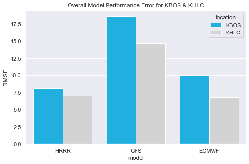

```python
sns.set_style("whitegrid")
sns.set(rc={'figure.figsize':(8,5)})
fig1 = sns.barplot(x="model",y="RMSE",hue="location",data=model_perf_loc,ci=None,palette=["deepskyblue","lightgrey"])
fig1.set_title("Overall Model Performance Error for KBOS & KHLC")
fig1 = fig1.get_figure()
fig1.savefig("figures/overall_model_perf_by_station.png")
```

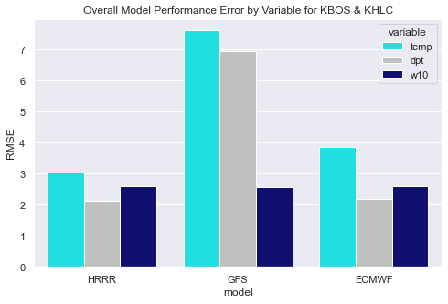

```python
sns.set_style("whitegrid")
sns.set(rc={'figure.figsize':(8,5)})
fig2 = sns.barplot(x="model",y="RMSE",hue="variable",data=model_perf_variables,ci=None,palette=["cyan","silver","navy"])
fig2.set_title("Overall Model Performance Error by Variable for KBOS & KHLC")
fig2 = fig2.get_figure()
fig2.savefig("figures/overall_model_perf_by_variable.png")
```

By variable we see that temperature prediction has the highest error. Dewpoint is the best in both the Euro & HRRR, however wind speed is the best performer for the GFS. Surprisingly, wind prediction with the GFS is on par with the HRRR & Euro, despite the very poor temp & dewpoint performance.

### 4. Bias Correction of Forecasts

In order to bias-correct the forecast data, a machine learning algorithm will be implemented. The reason that a machine learning approach will be taken is in my experience of using a simple mean diurnal cycle bias correction (subtracting the mean forecast by the mean observed between hours 0-23), this method is very difficult to scale up. If data is collected on seasonal/yearly basis, then a seasonal bias correction will need to occur, and even perhaps a yearly bias correction. ML algorithms are flexible, easier to scale up, and more often than not highly effective.

For temperature and wind speed bias correction, I have found that Gradient Boosted Trees or XGBoost perform often better than regular regression techniques. Therefore GBT from Sci-Kit Learn was selected.

###### Experiment

Two variables will be used as inputs, fcst_dt and the forecast variable. The METAR observation variables will be used as the targets. Fcst_dt will represent the temporal variation in the data, particularly how bias increases/decreases as the forecast increases in time. These two variables will be used to train the GBT model. In addition, a bias-correction model will be trained for each variable for each location, and this is to account for the typical differences in bias between two locations (KBOS & KHLC).

My hypothesis is that if GBT is used for bias correction, then temperature/dewpoint/windspeed will all significantly improve in respect to the observational data. However, wind speed will improve the least.

I will first train/test HRRR temperature forecasts for KBOS, then dew point, and windspeed and visualize the results. Then I will perform the training/testing for each model for each location and collect the results.

##### Temperature

```python
# Focus on KBOS first
KBOS_hrrr_analysis_df = hrrr_analysis_df[hrrr_analysis_df.pt=="KBOS"].dropna()
#KBOS_hrrr_analysis_df = KBOS_gfs_analysis_df

# use fcst_dt and model forecasted temperatures as inputs to the model, and the obs data as the target
X_KBOS_hrrr = KBOS_hrrr_analysis_df[["fcst_dt","sfc_air_temperature"]]
Y_KBOS_hrrr = KBOS_hrrr_analysis_df["temperature_c"]

# split into training/testing use 80/20 split
X_train, X_test, y_train, y_test = train_test_split(X_KBOS_hrrr, Y_KBOS_hrrr, test_size=0.2, random_state=42)
```

```python
# train a Gradient Boosted Tree algorithm and print the results
gbr = GradientBoostingRegressor(n_estimators=40)
gbr.fit(X_train,y_train)
pred = gbr.predict(X_test)

# print results
print(f"HRRR Forecast R2 Score: {r2_score(y_test,X_test.sfc_air_temperature)}")
print(f"HRRR Forecast RMSE: {mean_squared_error(y_test,X_test.sfc_air_temperature,squared=False)}")

print(f"Bias Corrected HRRR R2 Score: {r2_score(y_test,pred)}")
print(f"Bias Corrected HRRR RMSE: {mean_squared_error(y_test,pred,squared=False)}")
```

```
HRRR Forecast R2 Score: 0.46490406592092026
HRRR Forecast RMSE: 3.917417295405916
Bias Corrected HRRR R2 Score: 0.8726296447379525
Bias Corrected HRRR RMSE: 1.9112530478085996
```

```python
verify_temp = pd.concat([X_test,y_test],axis=1)
verify_temp["pred"] = pred
verify_temp_mean = verify_temp.groupby("fcst_dt").mean()
```

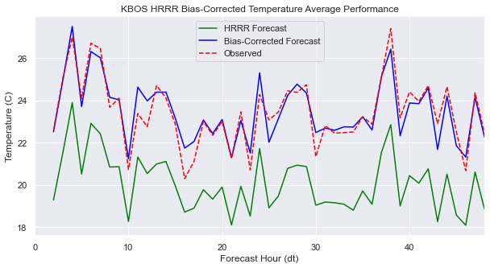

```python
plt.rcParams["figure.figsize"] = (10,5)
plt.plot(verify_temp_mean.index,verify_temp_mean.sfc_air_temperature,label="HRRR Forecast",c="green")
plt.plot(verify_temp_mean.index,verify_temp_mean.pred,label="Bias-Corrected Forecast",c="blue")
plt.plot(verify_temp_mean.index,verify_temp_mean.temperature_c,'--',label="Observed",c="red")
plt.legend()
plt.title("KBOS HRRR Bias-Corrected Temperature Average Performance")
plt.xlabel("Forecast Hour (dt)")
plt.ylabel("Temperature (C)")
plt.xlim([0,48])
plt.savefig("figures/KBOS_HRRR_bias_corrected_temp.png")
```

There is a clear improvement on the forecast as can be seen in the figure above.

Overall excellent results.

###### Dewpoint

```python
# Focus on KBOS first
KBOS_hrrr_analysis_df = hrrr_analysis_df[hrrr_analysis_df.pt=="KBOS"].dropna()

# use fcst_dt and model forecasted dewpoints as inputs to the model, and the obs data as the target
X_KBOS_hrrr = KBOS_hrrr_analysis_df[["fcst_dt","sfc_dewpoint"]]
Y_KBOS_hrrr = KBOS_hrrr_analysis_df["dewpoint_c"]

# split into training/testing use 80/20 split
X_train, X_test, y_train, y_test = train_test_split(X_KBOS_hrrr, Y_KBOS_hrrr, test_size=0.2, random_state=42)
```

```python
# train a Gradient Boosted Tree algorithm and print the results
gbr = GradientBoostingRegressor(n_estimators=80)
gbr.fit(X_train,y_train)
pred = gbr.predict(X_test)

# print results
print(f"HRRR Forecast R2 Score: {r2_score(y_test,X_test.sfc_dewpoint)}")
print(f"HRRR Forecast RMSE: {mean_squared_error(y_test,X_test.sfc_dewpoint,squared=False)}")

print(f"Bias Corrected HRRR R2 Score: {r2_score(y_test,pred)}")
print(f"Bias Corrected HRRR RMSE: {mean_squared_error(y_test,pred,squared=False)}")
```

```
HRRR Forecast R2 Score: 0.8460873187416739
HRRR Forecast RMSE: 1.8426903322511752
Bias Corrected HRRR R2 Score: 0.8584343745778492
Bias Corrected HRRR RMSE: 1.7672340119454324
```

```python
verify_dpt = pd.concat([X_test,y_test],axis=1)
verify_dpt["pred"] = pred
verify_dpt_mean = verify_dpt.groupby("fcst_dt").mean()
```

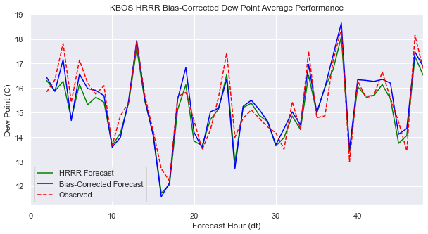

```python
plt.rcParams["figure.figsize"] = (10,5)
plt.plot(verify_dpt_mean.index,verify_dpt_mean.sfc_dewpoint,label="HRRR Forecast",c="green")
plt.plot(verify_dpt_mean.index,verify_dpt_mean.pred,label="Bias-Corrected Forecast",c="blue")
plt.plot(verify_dpt_mean.index,verify_dpt_mean.dewpoint_c,'--',label="Observed",c="red")
plt.legend()
plt.title("KBOS HRRR Bias-Corrected Dew Point Average Performance")
plt.xlabel("Forecast Hour (dt)")
plt.ylabel("Dew Point (C)")
plt.xlim([0,48])
plt.savefig("figures/KBOS_HRRR_bias_corrected_dpt.png")
```

Implementation of the GBT resulted in slightly improved results in comparison to the HRRR forecasted values, however it is worth noting that the HRRR already forecasted dewpoints accurately. Slight improvements were found in R2-score and RMSE.

###### Wind Speed

```python
# Focus on KBOS first
KBOS_hrrr_analysis_df = hrrr_analysis_df[hrrr_analysis_df.pt=="KBOS"].dropna()

# use fcst_dt and model forecasted dewpoints as inputs to the model, and the obs data as the target
X_KBOS_hrrr = KBOS_hrrr_analysis_df[["fcst_dt","wind_speed_ms"]]
Y_KBOS_hrrr = KBOS_hrrr_analysis_df["wind_10m"]

# split into training/testing use 80/20 split
X_train, X_test, y_train, y_test = train_test_split(X_KBOS_hrrr, Y_KBOS_hrrr, test_size=0.2, random_state=42)
```

```python
# train a Gradient Boosted Tree algorithm and print the results
gbr = GradientBoostingRegressor(n_estimators=40)
gbr.fit(X_train,y_train)
pred = gbr.predict(X_test)

# print results
print(f"HRRR Forecast R2 Score: {r2_score(y_test,X_test.wind_speed_ms)}")
print(f"HRRR Forecast RMSE: {mean_squared_error(y_test,X_test.wind_speed_ms,squared=False)}")

print(f"Bias Corrected HRRR R2 Score: {r2_score(y_test,pred)}")
print(f"Bias Corrected HRRR RMSE: {mean_squared_error(y_test,pred,squared=False)}")
```

```
HRRR Forecast R2 Score: -1.2017527399349905
HRRR Forecast RMSE: 2.422061356807932
Bias Corrected HRRR R2 Score: 0.3887294549488687
Bias Corrected HRRR RMSE: 1.2761966567359373
```

```python
verify_w10 = pd.concat([X_test,y_test],axis=1)
verify_w10["pred"] = pred
verify_w10_mean = verify_w10.groupby("fcst_dt").mean()
```

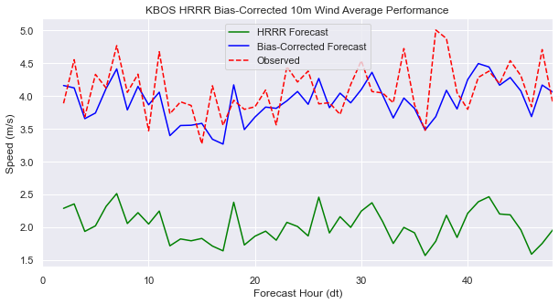

```python
plt.rcParams["figure.figsize"] = (10,5)
plt.plot(verify_w10_mean.index,verify_w10_mean.wind_speed_ms,label="HRRR Forecast",c="green")
plt.plot(verify_w10_mean.index,verify_w10_mean.pred,label="Bias-Corrected Forecast",c="blue")
plt.plot(verify_w10_mean.index,verify_w10_mean.wind_10m,'--',label="Observed",c="red")
plt.legend()
plt.title("KBOS HRRR Bias-Corrected 10m Wind Average Performance")
plt.xlabel("Forecast Hour (dt)")
plt.ylabel("Speed (m/s)")
plt.xlim([0,48])
plt.savefig("figures/KBOS_HRRR_bias_corrected_w10.png")
```

Again outstanding improvements were found with wind speed, contrary to my hypothesis which thought this area would see the least improvement.

###### Correct remaining models and locations

```python
# redefine the analysis dataframes do contain all forecast hours rather than 0-48z only
gfs_analysis_df = Preprocessing.merge_forecast_with_obs([BOS_gfs_processed,HLC_gfs_processed],[BOS_obs_processed,HLC_obs_processed],None)
hrrr_analysis_df = Preprocessing.merge_forecast_with_obs([BOS_hrrr_processed,HLC_hrrr_processed],[BOS_obs_processed,HLC_obs_processed],None)
ecmwf_analysis_df = Preprocessing.merge_forecast_with_obs([BOS_ecmwf_processed,HLC_ecmwf_processed],[BOS_obs_processed,HLC_obs_processed],None)


# Define the remaining models and stations
KBOS_hrrr_analysis_df = hrrr_analysis_df[hrrr_analysis_df.pt=="KBOS"].dropna()
KHLC_hrrr_analysis_df = hrrr_analysis_df[hrrr_analysis_df.pt=="KHLC"].dropna()
KBOS_gfs_analysis_df = gfs_analysis_df[gfs_analysis_df.pt=="KBOS"].dropna()
KHLC_gfs_analysis_df = gfs_analysis_df[gfs_analysis_df.pt=="KHLC"].dropna()
KBOS_ecmwf_analysis_df = ecmwf_analysis_df[ecmwf_analysis_df.pt=="KBOS"].dropna()
KHLC_ecmwf_analysis_df = ecmwf_analysis_df[ecmwf_analysis_df.pt=="KHLC"].dropna()
```

```python
# calculate bias-corrected performance from all models/stations
KBOS_hrrr_results = Bias_Correction.gradient_boosted_trees_bias_correction(KBOS_hrrr_analysis_df,"KBOS","HRRR")
KHLC_hrrr_results = Bias_Correction.gradient_boosted_trees_bias_correction(KHLC_hrrr_analysis_df,"KHLC","HRRR")
KBOS_gfs_results = Bias_Correction.gradient_boosted_trees_bias_correction(KBOS_gfs_analysis_df,"KBOS","GFS")
KHLC_gfs_results = Bias_Correction.gradient_boosted_trees_bias_correction(KHLC_gfs_analysis_df,"KHLC","GFS")
KBOS_ecmwf_results = Bias_Correction.gradient_boosted_trees_bias_correction(KBOS_ecmwf_analysis_df,"KBOS","ECMWF")
KHLC_ecmwf_results = Bias_Correction.gradient_boosted_trees_bias_correction(KHLC_ecmwf_analysis_df,"KHLC","ECMWF")

# concat all results for plotting
bias_corrected_results = pd.concat([KBOS_hrrr_results,KHLC_hrrr_results,KBOS_gfs_results,KHLC_gfs_results,KBOS_ecmwf_results,KHLC_ecmwf_results])
bias_corrected_results
```

|  | variable | rmse | method | model | location |
| --- | --- | --- | --- | --- | --- |
| 0 | temp | 1.911253 | bias-corrected | HRRR | KBOS |
| 1 | dpt | 1.761046 | bias-corrected | HRRR | KBOS |
| 2 | w10 | 1.276197 | bias-corrected | HRRR | KBOS |
| 3 | temp | 3.917417 | raw forecast | HRRR | KBOS |
| 4 | dpt | 1.842690 | raw forecast | HRRR | KBOS |
| 5 | w10 | 2.422061 | raw forecast | HRRR | KBOS |
| 0 | temp | 1.790336 | bias-corrected | HRRR | KHLC |
| 1 | dpt | 1.715269 | bias-corrected | HRRR | KHLC |
| 2 | w10 | 1.558331 | bias-corrected | HRRR | KHLC |
| 3 | temp | 1.842512 | raw forecast | HRRR | KHLC |
| 4 | dpt | 2.227792 | raw forecast | HRRR | KHLC |
| 5 | w10 | 2.714450 | raw forecast | HRRR | KHLC |
| 0 | temp | 5.302645 | bias-corrected | GFS | KBOS |
| 1 | dpt | 4.696667 | bias-corrected | GFS | KBOS |
| 2 | w10 | 1.116399 | bias-corrected | GFS | KBOS |
| 3 | temp | 7.822905 | raw forecast | GFS | KBOS |
| 4 | dpt | 8.518990 | raw forecast | GFS | KBOS |
| 5 | w10 | 1.432822 | raw forecast | GFS | KBOS |
| 0 | temp | 5.838239 | bias-corrected | GFS | KHLC |
| 1 | dpt | 3.182331 | bias-corrected | GFS | KHLC |
| 2 | w10 | 2.344607 | bias-corrected | GFS | KHLC |
| 3 | temp | 7.002366 | raw forecast | GFS | KHLC |
| 4 | dpt | 4.477176 | raw forecast | GFS | KHLC |
| 5 | w10 | 3.419336 | raw forecast | GFS | KHLC |
| 0 | temp | 2.574287 | bias-corrected | ECMWF | KBOS |
| 1 | dpt | 2.533256 | bias-corrected | ECMWF | KBOS |
| 2 | w10 | 1.431000 | bias-corrected | ECMWF | KBOS |
| 3 | temp | 5.121763 | raw forecast | ECMWF | KBOS |
| 4 | dpt | 2.836097 | raw forecast | ECMWF | KBOS |
| 5 | w10 | 2.912786 | raw forecast | ECMWF | KBOS |
| 0 | temp | 2.738627 | bias-corrected | ECMWF | KHLC |
| 1 | dpt | 2.338470 | bias-corrected | ECMWF | KHLC |
| 2 | w10 | 1.427217 | bias-corrected | ECMWF | KHLC |
| 3 | temp | 2.809409 | raw forecast | ECMWF | KHLC |
| 4 | dpt | 3.069157 | raw forecast | ECMWF | KHLC |
| 5 | w10 | 2.534300 | raw forecast | ECMWF | KHLC |

###### Plot of bias-corrected versus raw forecast data

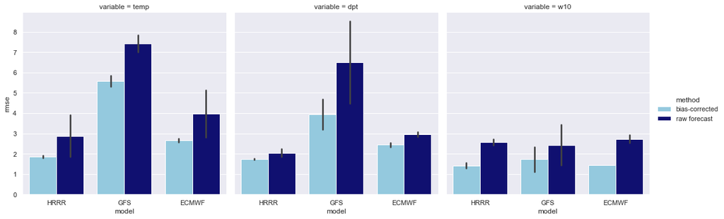

```python
# Plot of the bias-corrected data vs the raw forecast data
sns.set_style("whitegrid")
sns.set(rc={'figure.figsize':(10,5)})
fig3 = sns.catplot(x='model',y="rmse",hue="method",col = "variable",kind="bar",data=bias_corrected_results,palette=["skyblue","navy"])
fig3.savefig("figures/bias_corrected_vs_raw.png")
```

###### Overall Improvement

```python
# collect overall improvement by model and method
bias_corrected_results_overall = bias_corrected_results.groupby(["method","model"]).mean()
```

```python
# calculate the % improvement
corrected_rmse = bias_corrected_results_overall.rmse["bias-corrected"]
raw_rmse = bias_corrected_results_overall.rmse["raw forecast"]

perc_improvement =  ((abs(corrected_rmse - raw_rmse)) / raw_rmse) * 100



print(f"Bias Correction of the ECMWF resulted in a {perc_improvement.ECMWF.round(1)}% overall improved forecast")
print(f"Bias Correction of the GFS resulted in a {perc_improvement.GFS.round(1)}% overall improved forecast")
print(f"Bias Correction of the HRRR resulted in a {perc_improvement.HRRR.round(1)}% overall improved forecast")
```

```
Bias Correction of the ECMWF resulted in a 32.4% overall improved forecast
Bias Correction of the GFS resulted in a 31.2% overall improved forecast
Bias Correction of the HRRR resulted in a 33.1% overall improved forecast
```

```python
# calculate overall improvement across all models
mean_rmse_bias = bias_corrected_results_overall.rmse["bias-corrected"].mean()
mean_rmse_raw = bias_corrected_results_overall.rmse["raw forecast"].mean()

overall_perc_improvement = (abs(mean_rmse_bias - mean_rmse_raw) / mean_rmse_raw) * 100
print(f"Bias Correction resulted in a {overall_perc_improvement.round(1)}% overall improved forecast")
```

```
Bias Correction resulted in a 32.0% overall improved forecast
```